# Chapter 3 Assignment

Joe Dickerson

2025-09-07

Problem 9.

```r
library("ISLR")
```

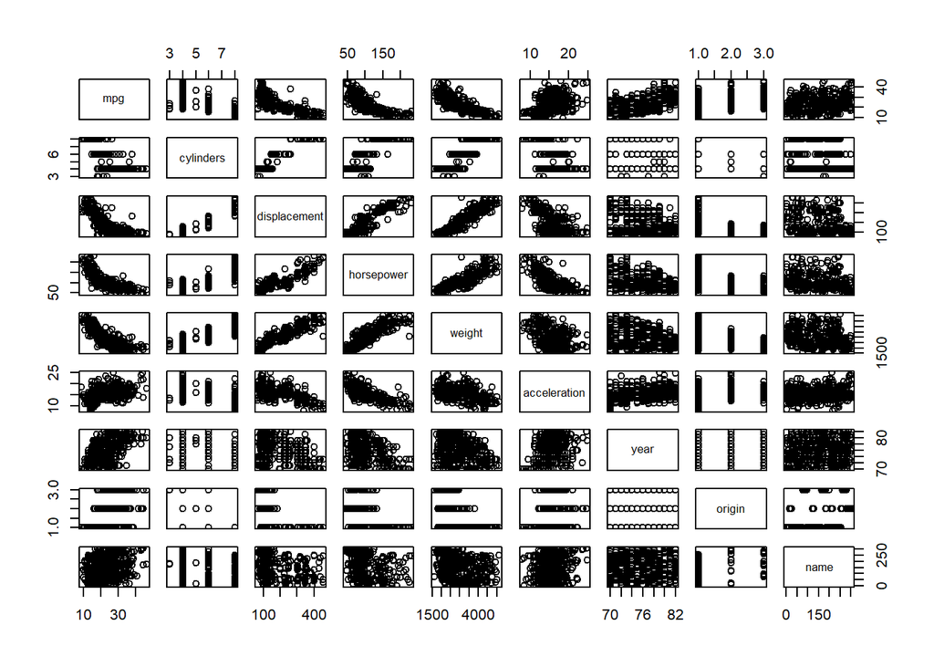

```r
data(Auto, package="ISLR")

pairs(Auto)
```

```r
cor(Auto[, -9])
```

```
##                     mpg  cylinders displacement horsepower     weight
## mpg           1.0000000 -0.7776175   -0.8051269 -0.7784268 -0.8322442
## cylinders    -0.7776175  1.0000000    0.9508233  0.8429834  0.8975273
## displacement -0.8051269  0.9508233    1.0000000  0.8972570  0.9329944
## horsepower   -0.7784268  0.8429834    0.8972570  1.0000000  0.8645377
## weight       -0.8322442  0.8975273    0.9329944  0.8645377  1.0000000
## acceleration  0.4233285 -0.5046834   -0.5438005 -0.6891955 -0.4168392
## year          0.5805410 -0.3456474   -0.3698552 -0.4163615 -0.3091199
## origin        0.5652088 -0.5689316   -0.6145351 -0.4551715 -0.5850054
##              acceleration       year     origin
## mpg             0.4233285  0.5805410  0.5652088
## cylinders      -0.5046834 -0.3456474 -0.5689316
## displacement   -0.5438005 -0.3698552 -0.6145351
## horsepower     -0.6891955 -0.4163615 -0.4551715
## weight         -0.4168392 -0.3091199 -0.5850054
## acceleration    1.0000000  0.2903161  0.2127458
## year            0.2903161  1.0000000  0.1815277
## origin          0.2127458  0.1815277  1.0000000
```

4. There does appear to be a relationship between the predictors and the response, however not all predictors seem to have a relationship.
2. Displacement, weight, year, and origin appear to have statistical significance.
3. With all other predictors constant, we would expect the mpg to increase by 0.751 each additional year.

```r
lmod <- lm(mpg ~ . -name, data=Auto)
summary(lmod)
```

```
##
## Call:
## lm(formula = mpg ~ . - name, data = Auto)
##
## Residuals:
##     Min      1Q  Median      3Q     Max
## -9.5903 -2.1565 -0.1169  1.8690 13.0604
##
## Coefficients:
##                Estimate Std. Error t value Pr(>|t|)
## (Intercept)  -17.218435   4.644294  -3.707  0.00024 ***
## cylinders     -0.493376   0.323282  -1.526  0.12780
## displacement   0.019896   0.007515   2.647  0.00844 **
## horsepower    -0.016951   0.013787  -1.230  0.21963
## weight        -0.006474   0.000652  -9.929  < 2e-16 ***
## acceleration   0.080576   0.098845   0.815  0.41548
## year           0.750773   0.050973  14.729  < 2e-16 ***
## origin         1.426141   0.278136   5.127 4.67e-07 ***
## ---
## Signif. codes:  0 '***' 0.001 '**' 0.01 '*' 0.05 '.' 0.1 ' ' 1
##
## Residual standard error: 3.328 on 384 degrees of freedom
## Multiple R-squared:  0.8215, Adjusted R-squared:  0.8182
## F-statistic: 252.4 on 7 and 384 DF,  p-value: < 2.2e-16
```

4. There appears to be some nonlinearity in our residuals vs fitted values graph. The Q-Q plot shows normally distributed residuals, though they may be skewed to the right. There is an outlier on the leverage plot, and it is labeled as observation 14.

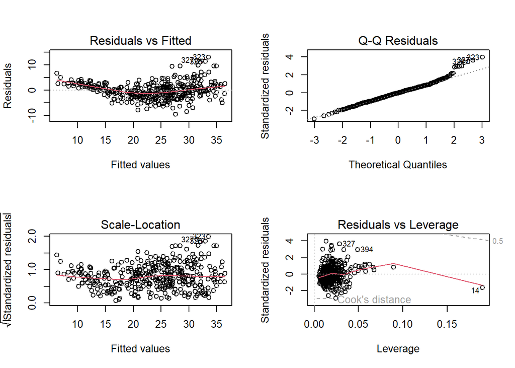

```r
par(mfrow = c(2,2))
plot(lmod)
```

5. The interaction term between weight and displacement appears statistically significant as it has a very small p-value. We see the same result when creating an interaction between weight and year, which suggests statistical significance. However, when we make an interaction between weight and year using :, which creates an interaction without the main effects, the interaction loses its statistical significance.

```r
lmod2 <- lm(mpg ~ weight*displacement + year + origin + horsepower + cylinders + acceleration, data=Auto)

summary(lmod2)
```

```
##
## Call:
## lm(formula = mpg ~ weight * displacement + year + origin + horsepower +
##     cylinders + acceleration, data = Auto)
##
## Residuals:
##     Min      1Q  Median      3Q     Max
## -9.9027 -1.8092 -0.0946  1.5549 12.1687
##
## Coefficients:
##                       Estimate Std. Error t value Pr(>|t|)
## (Intercept)         -5.389e+00  4.301e+00  -1.253   0.2109
## weight              -1.064e-02  7.136e-04 -14.915  < 2e-16 ***
## displacement        -6.837e-02  1.104e-02  -6.193 1.52e-09 ***
## year                 7.852e-01  4.553e-02  17.246  < 2e-16 ***
## origin               5.610e-01  2.622e-01   2.139   0.0331 *
## horsepower          -3.280e-02  1.238e-02  -2.649   0.0084 **
## cylinders            1.175e-01  2.943e-01   0.399   0.6899
## acceleration         6.724e-02  8.805e-02   0.764   0.4455
## weight:displacement  2.269e-05  2.257e-06  10.054  < 2e-16 ***
## ---
## Signif. codes:  0 '***' 0.001 '**' 0.01 '*' 0.05 '.' 0.1 ' ' 1
##
## Residual standard error: 2.964 on 383 degrees of freedom
## Multiple R-squared:  0.8588, Adjusted R-squared:  0.8558
## F-statistic: 291.1 on 8 and 383 DF,  p-value: < 2.2e-16
```

```r
lmod3 <- lm(mpg ~ weight*year + displacement + origin + horsepower + cylinders + acceleration, data=Auto)

summary(lmod3)
```

```
##
## Call:
## lm(formula = mpg ~ weight * year + displacement + origin + horsepower +
##     cylinders + acceleration, data = Auto)
##
## Residuals:
##     Min      1Q  Median      3Q     Max
## -7.9995 -1.8495 -0.1559  1.6061 11.7042
##
## Coefficients:
##                Estimate Std. Error t value Pr(>|t|)
## (Intercept)  -1.186e+02  1.338e+01  -8.864  < 2e-16 ***
## weight        3.044e-02  4.652e-03   6.543 1.94e-10 ***
## year          2.084e+00  1.732e-01  12.033  < 2e-16 ***
## displacement  1.293e-02  7.019e-03   1.842   0.0663 .
## origin        1.174e+00  2.597e-01   4.519 8.30e-06 ***
## horsepower   -2.877e-02  1.286e-02  -2.236   0.0259 *
## cylinders    -1.218e-01  3.032e-01  -0.402   0.6881
## acceleration  1.447e-01  9.196e-02   1.574   0.1164
## weight:year  -4.879e-04  6.097e-05  -8.002 1.47e-14 ***
## ---
## Signif. codes:  0 '***' 0.001 '**' 0.01 '*' 0.05 '.' 0.1 ' ' 1
##
## Residual standard error: 3.084 on 383 degrees of freedom
## Multiple R-squared:  0.847,  Adjusted R-squared:  0.8439
## F-statistic: 265.1 on 8 and 383 DF,  p-value: < 2.2e-16
```

```r
lmod4 <- lm(mpg ~ weight:year + displacement + origin + horsepower + cylinders + acceleration, data=Auto)

summary(lmod4)
```

```
##
## Call:
## lm(formula = mpg ~ weight:year + displacement + origin + horsepower +
##     cylinders + acceleration, data = Auto)
##
## Residuals:
##      Min       1Q   Median       3Q      Max
## -13.3185  -2.9781  -0.3238   2.1566  15.2337
##
## Coefficients:
##                Estimate Std. Error t value Pr(>|t|)
## (Intercept)   4.440e+01  2.817e+00  15.763  < 2e-16 ***
## displacement -4.366e-03  9.528e-03  -0.458    0.647
## origin        1.613e+00  3.625e-01   4.449 1.13e-05 ***
## horsepower   -9.816e-02  1.661e-02  -5.909 7.59e-09 ***
## cylinders    -7.916e-01  4.213e-01  -1.879    0.061 .
## acceleration -3.051e-01  1.249e-01  -2.443    0.015 *
## weight:year  -1.472e-05  9.409e-06  -1.564    0.119
## ---
## Signif. codes:  0 '***' 0.001 '**' 0.01 '*' 0.05 '.' 0.1 ' ' 1
##
## Residual standard error: 4.337 on 385 degrees of freedom
## Multiple R-squared:  0.6959, Adjusted R-squared:  0.6912
## F-statistic: 146.9 on 6 and 385 DF,  p-value: < 2.2e-16
```

6. We still see statistical significance when doing a log transformation on weight, and when squaring displacement. We also see statistical significance when taking the square root of year.

```r
lmod5 <- lm(mpg ~ log(weight) + displacement^2 + year + origin + horsepower + cylinders + acceleration, data=Auto)

summary(lmod5)
```

```
##
## Call:
## lm(formula = mpg ~ log(weight) + displacement^2 + year + origin +
##     horsepower + cylinders + acceleration, data = Auto)
##
## Residuals:
##    Min     1Q Median     3Q    Max
## -9.382 -1.973 -0.016  1.681 12.803
##
## Coefficients:
##                Estimate Std. Error t value Pr(>|t|)
## (Intercept)  133.138912  11.531157  11.546  < 2e-16 ***
## log(weight)  -21.858785   1.651400 -13.237  < 2e-16 ***
## displacement   0.020977   0.006825   3.074 0.002265 **
## year           0.788784   0.047596  16.573  < 2e-16 ***
## origin         1.011407   0.262262   3.856 0.000135 ***
## horsepower    -0.010072   0.012546  -0.803 0.422593
## cylinders     -0.432749   0.299977  -1.443 0.149946
## acceleration   0.135179   0.089798   1.505 0.133051
## ---
## Signif. codes:  0 '***' 0.001 '**' 0.01 '*' 0.05 '.' 0.1 ' ' 1
##
## Residual standard error: 3.091 on 384 degrees of freedom
## Multiple R-squared:  0.8459, Adjusted R-squared:  0.8431
## F-statistic: 301.2 on 7 and 384 DF,  p-value: < 2.2e-16
```

```r
lmod6 <- lm(mpg ~ weight + displacement + sqrt(year) + origin + horsepower + cylinders + acceleration, data=Auto)

summary(lmod6)
```

```
##
## Call:
## lm(formula = mpg ~ weight + displacement + sqrt(year) + origin +
##     horsepower + cylinders + acceleration, data = Auto)
##
## Residuals:
##     Min      1Q  Median      3Q     Max
## -9.6195 -2.1637 -0.1137  1.8838 13.0746
##
## Coefficients:
##                Estimate Std. Error t value Pr(>|t|)
## (Intercept)  -7.376e+01  8.289e+00  -8.898  < 2e-16 ***
## weight       -6.496e-03  6.539e-04  -9.935  < 2e-16 ***
## displacement  2.005e-02  7.534e-03   2.661  0.00811 **
## sqrt(year)    1.304e+01  8.911e-01  14.632  < 2e-16 ***
## origin        1.425e+00  2.788e-01   5.112 5.04e-07 ***
## horsepower   -1.670e-02  1.383e-02  -1.208  0.22790
## cylinders    -4.998e-01  3.240e-01  -1.542  0.12381
## acceleration  8.124e-02  9.909e-02   0.820  0.41281
## ---
## Signif. codes:  0 '***' 0.001 '**' 0.01 '*' 0.05 '.' 0.1 ' ' 1
##
## Residual standard error: 3.336 on 384 degrees of freedom
## Multiple R-squared:  0.8206, Adjusted R-squared:  0.8174
## F-statistic:   251 on 7 and 384 DF,  p-value: < 2.2e-16
```

Problem 14.

The form of the linear model is a function of x1 and x2

y = 2 + 2$x_1$ + 0.3$x_2$ + rnorm(100)

```r
set.seed(1)
x1 <- runif(100)
x2 <- 0.5 * x1 + rnorm(100) / 10
y <- 2 + 2 * x1 + 0.3 * x2 + rnorm(100)
```

2. We see a positive correlation between x1 and x2. The correlation found using the cor() function is 0.8351

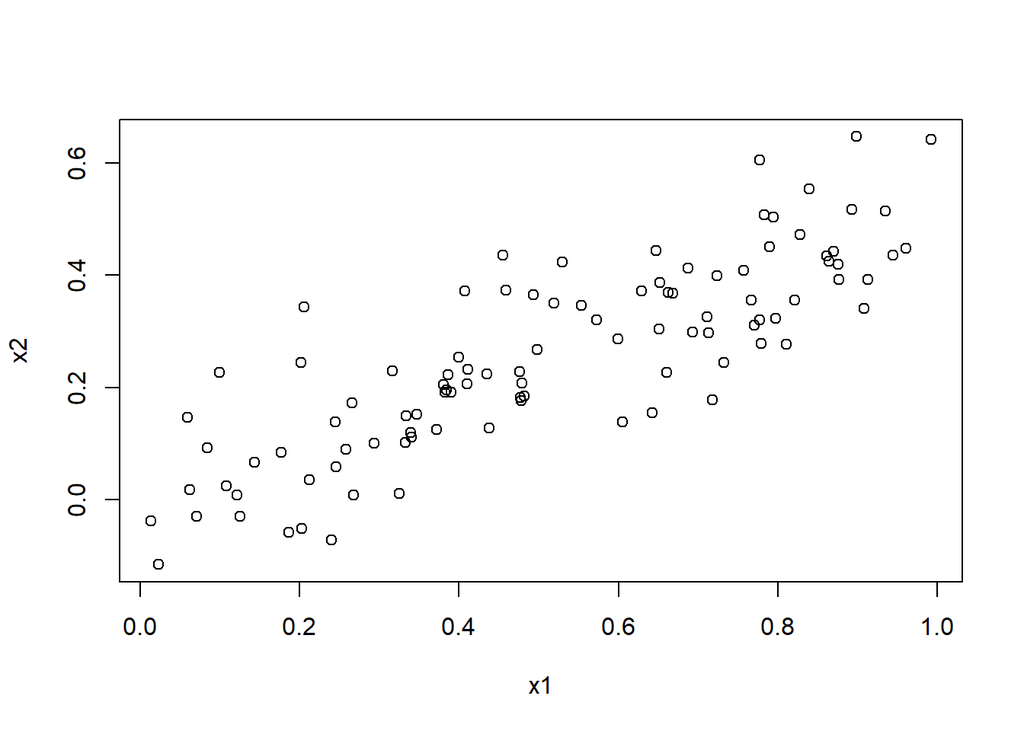

```r
plot(x1, x2)
```

```r
cor(x1, x2)
```

```
## [1] 0.8351212
```

$\hat{\beta}_0$ = 2.131

$\hat{\beta}_1$ = 1.440

$\hat{\beta}_2$ = 1.010

```r
lm1 <- lm(y ~ x1 + x2)

summary(lm1)
```

```
##
## Call:
## lm(formula = y ~ x1 + x2)
##
## Residuals:
##     Min      1Q  Median      3Q     Max
## -2.8311 -0.7273 -0.0537  0.6338  2.3359
##
## Coefficients:
##             Estimate Std. Error t value Pr(>|t|)
## (Intercept)   2.1305     0.2319   9.188 7.61e-15 ***
## x1            1.4396     0.7212   1.996   0.0487 *
## x2            1.0097     1.1337   0.891   0.3754
## ---
## Signif. codes:  0 '***' 0.001 '**' 0.01 '*' 0.05 '.' 0.1 ' ' 1
##
## Residual standard error: 1.056 on 97 degrees of freedom
## Multiple R-squared:  0.2088, Adjusted R-squared:  0.1925
## F-statistic:  12.8 on 2 and 97 DF,  p-value: 1.164e-05
```

When we include only x1, the coefficient is even closer to our beta value of 2. We also see a much smaller p-value. We can reject the null hypothesis of B1 = 0.

```r
lm2 <- lm(y ~ x1)

summary(lm2)
```

```
##
## Call:
## lm(formula = y ~ x1)
##
## Residuals:
##      Min       1Q   Median       3Q      Max
## -2.89495 -0.66874 -0.07785  0.59221  2.45560
##
## Coefficients:
##             Estimate Std. Error t value Pr(>|t|)
## (Intercept)   2.1124     0.2307   9.155 8.27e-15 ***
## x1            1.9759     0.3963   4.986 2.66e-06 ***
## ---
## Signif. codes:  0 '***' 0.001 '**' 0.01 '*' 0.05 '.' 0.1 ' ' 1
##
## Residual standard error: 1.055 on 98 degrees of freedom
## Multiple R-squared:  0.2024, Adjusted R-squared:  0.1942
## F-statistic: 24.86 on 1 and 98 DF,  p-value: 2.661e-06
```

5. When we only include x2 in the model, it becomes significant with a very small p-value. With this model alone, it appears the null hypothesis can be rejected.

```r
lm3 <- lm(y ~ x2)

summary(lm3)
```

```
##
## Call:
## lm(formula = y ~ x2)
##
## Residuals:
##      Min       1Q   Median       3Q      Max
## -2.62687 -0.75156 -0.03598  0.72383  2.44890
##
## Coefficients:
##             Estimate Std. Error t value Pr(>|t|)
## (Intercept)   2.3899     0.1949   12.26  < 2e-16 ***
## x2            2.8996     0.6330    4.58 1.37e-05 ***
## ---
## Signif. codes:  0 '***' 0.001 '**' 0.01 '*' 0.05 '.' 0.1 ' ' 1
##
## Residual standard error: 1.072 on 98 degrees of freedom
## Multiple R-squared:  0.1763, Adjusted R-squared:  0.1679
## F-statistic: 20.98 on 1 and 98 DF,  p-value: 1.366e-05
```

The results appear to contradict each other, as the first model cannot reject the null hypothesis while the following two can. It appears that there is some aspect of the predictors that create a lot of noise when observed together.

```r
x1 <- c(x1, 0.1)
x2 <- c(x2, 0.8)
y <- c(y, 6)

lm4 <- lm(y ~ x1 + x2)

summary(lm4)
```

```
##
## Call:
## lm(formula = y ~ x1 + x2)
##
## Residuals:
##      Min       1Q   Median       3Q      Max
## -2.73348 -0.69318 -0.05263  0.66385  2.30619
##
## Coefficients:
##             Estimate Std. Error t value Pr(>|t|)
## (Intercept)   2.2267     0.2314   9.624 7.91e-16 ***
## x1            0.5394     0.5922   0.911  0.36458
## x2            2.5146     0.8977   2.801  0.00614 **
## ---
## Signif. codes:  0 '***' 0.001 '**' 0.01 '*' 0.05 '.' 0.1 ' ' 1
##
## Residual standard error: 1.075 on 98 degrees of freedom
## Multiple R-squared:  0.2188, Adjusted R-squared:  0.2029
## F-statistic: 13.72 on 2 and 98 DF,  p-value: 5.564e-06
```

```r
lm5 <- lm(y ~ x1)

summary(lm5)
```

```
##
## Call:
## lm(formula = y ~ x1)
##
## Residuals:
##     Min      1Q  Median      3Q     Max
## -2.8897 -0.6556 -0.0909  0.5682  3.5665
##
## Coefficients:
##             Estimate Std. Error t value Pr(>|t|)
## (Intercept)   2.2569     0.2390   9.445 1.78e-15 ***
## x1            1.7657     0.4124   4.282 4.29e-05 ***
## ---
## Signif. codes:  0 '***' 0.001 '**' 0.01 '*' 0.05 '.' 0.1 ' ' 1
##
## Residual standard error: 1.111 on 99 degrees of freedom
## Multiple R-squared:  0.1562, Adjusted R-squared:  0.1477
## F-statistic: 18.33 on 1 and 99 DF,  p-value: 4.295e-05
```

```r
lm6 <- lm(y ~ x2)

summary(lm6)
```

```
##
## Call:
## lm(formula = y ~ x2)
##
## Residuals:
##      Min       1Q   Median       3Q      Max
## -2.64729 -0.71021 -0.06899  0.72699  2.38074
##
## Coefficients:
##             Estimate Std. Error t value Pr(>|t|)
## (Intercept)   2.3451     0.1912  12.264  < 2e-16 ***
## x2            3.1190     0.6040   5.164 1.25e-06 ***
## ---
## Signif. codes:  0 '***' 0.001 '**' 0.01 '*' 0.05 '.' 0.1 ' ' 1
##
## Residual standard error: 1.074 on 99 degrees of freedom
## Multiple R-squared:  0.2122, Adjusted R-squared:  0.2042
## F-statistic: 26.66 on 1 and 99 DF,  p-value: 1.253e-06
```

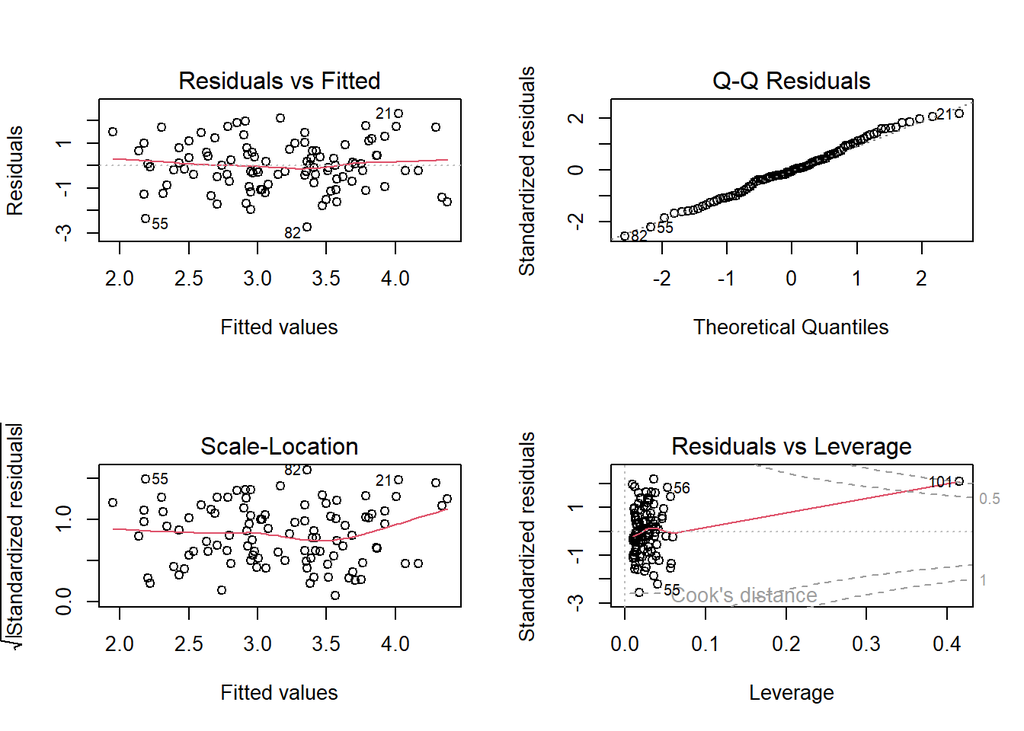

```r
par(mfrow = c(2,2))
plot(lm4)
```

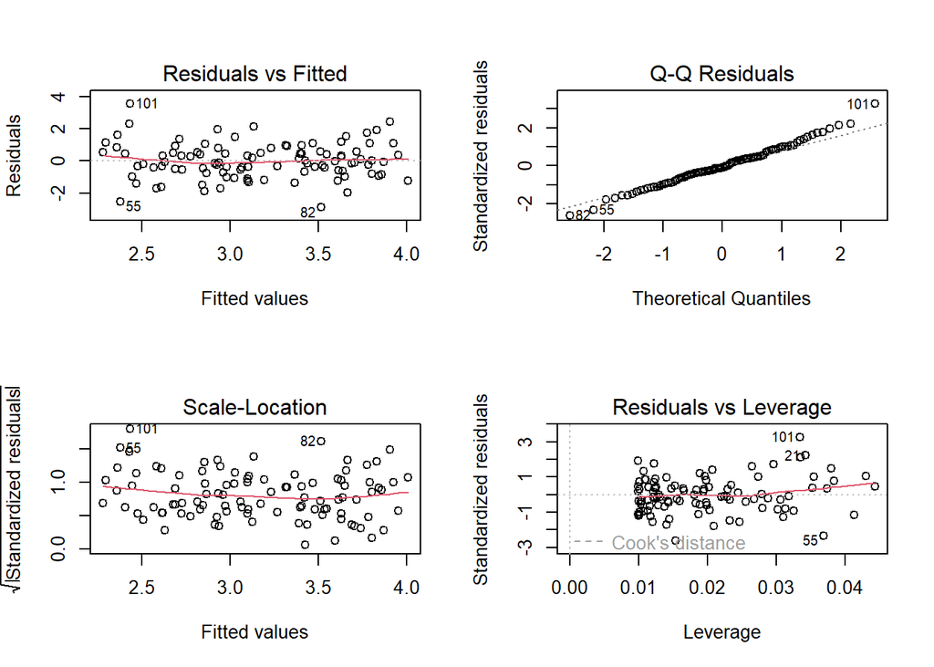

```r
par(mfrow = c(2,2))
plot(lm5)
```

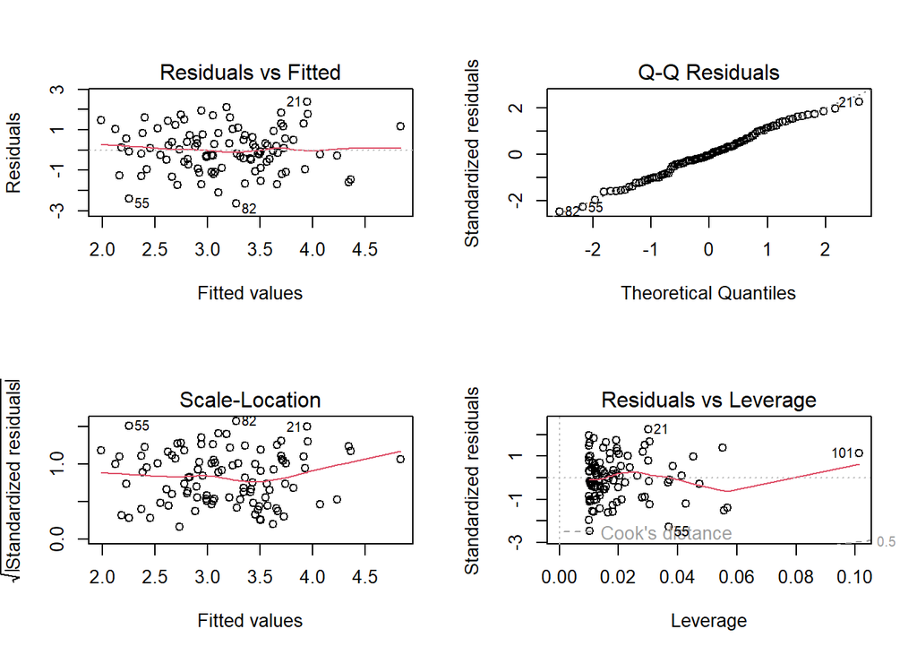

```r
par(mfrow = c(2,2))
plot(lm6)
```